# Developing Data Products

## Introduction

For most people, dealing with countinuous variables is a big problem. How to devide those variables into different groups without losing a lot of information? This application is able to solve this problem in the data from Bike Sharing Demand competition.

The dataset it used is in Bike Sharing Demand competition from Kaggle.com. It combines historical rental records in Washington, D.C., weather data, type of date and other information. It is provided by Fanaee-T, Hadi, and Gama, Joao, Event labeling combining ensemble detectors and background knowledge, Progress in Artificial Intelligence (2013): pp. 1-15, Springer Berlin Heidelberg.

If you want more information relating to the dataset or the competition, please visit the website. "https://www.kaggle.com/c/bike-sharing-demand".

## Introduction

In this application, you can devide the time variable into at most four groups by just entering the starting time and the ending time in the blank.

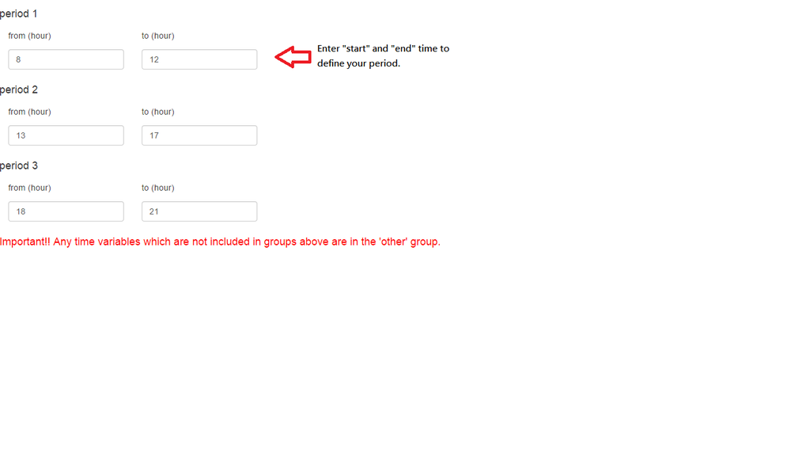

## Introduction

After you defined your periods, pressing "Go" button to to show the outcome of periods you defining.

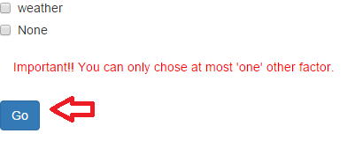

## Introduction

After pressing "Go" button, there are two tables and one plot telling the outcome of each period you defining. The first table says how many observations in each group. The second table informs you the mean of rentals in each group. In the plot, it shows the number of rentals in the density plots. With this information, we are able to find out the best ways to define the groups of time without losing important information.

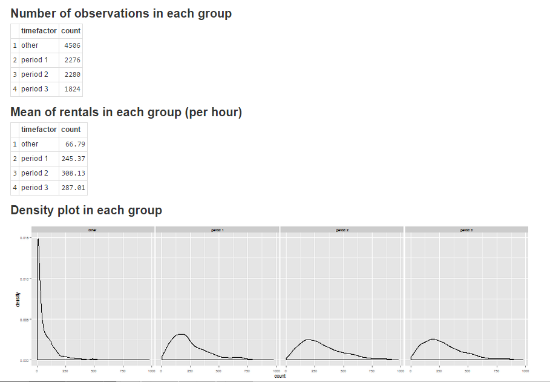

## Introduction

If you are worrying about the interaction between the groups of time you defined and other factor variables, there is a function that can help you. In "Other Factor" part, you can choose at most one factor included in the dataset to see the outcome of your groups under different factors.

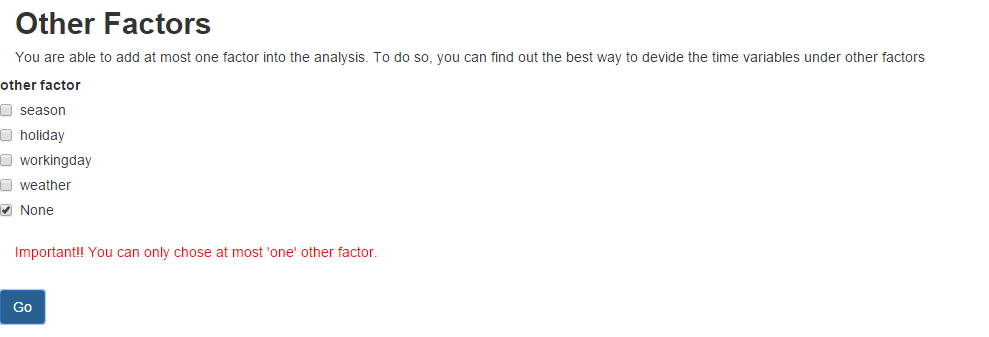

## Thank you for your usage

Thank you for your usage. Hope you'll have a great analysis in the competition!

*This web is designed by Barry Pan (Panda)*